# Prac_Mach_Learn Proj

# Synopsis

## Data has been collected from accelerometers on the belt, forearm, arm, and dumbell of 6 participants using the fitness devices such as Jawbone Up, Nike FuelBand, and Fitbit. The participants were asked to perform barbell lifts correctly and incorrectly in 5 different ways. More information is available from the website here: http://groupware.les.inf.puc-rio.br/har

## The goal of this project is to predict the manner in which they did the exercise. This is the “classe” variable in the training set.

# Reading data

## The training data for this project are available here:

## https://d396qusza40orc.cloudfront.net/predmachlearn/pml-training.csv

## The test data are available here:

## https://d396qusza40orc.cloudfront.net/predmachlearn/pml-testing.csv

## The data for this project come from this source: ##http://groupware.les.inf.puc-rio.br/har.

```r
# Reading training and testing data
training_dt <- read.csv("https://d396qusza40orc.cloudfront.net/predmachlearn/pml-training.csv", header=TRUE, na.strings = c("NA","NAN", ""), row.names = 1)
testing_dt <- read.csv("https://d396qusza40orc.cloudfront.net/predmachlearn/pml-testing.csv", header=TRUE, na.strings = c("NA","NAN", ""), row.names = 1)
```

# Initialysing

## Loaded in the required library and set the seed to 111, for reproducibility

```r
#Initialysing
library(caret)
```

```r
library(ggplot2)
library(rattle)
library(randomForest)
set.seed(111)
```

# Data processing

## As we need to perform prediction on the classe variable against all the other variables, we need to remove those unwanted or not useful variables. Removed the columns with NAs. And also reviewed the data set and removed the first 6 columns which is not needed for this analysis

```r
#Removing the columns with NAs
new_training <-training_dt[,colSums(is.na(training_dt)) == 0]
new_testing <-testing_dt[,colSums(is.na(testing_dt)) == 0]

str(new_training)
```

```
## 'data.frame':    19622 obs. of  59 variables:
##  $ user_name           : Factor w/ 6 levels "adelmo","carlitos",..: 2 2 2 2 2 2 2 2 2 2 ...
##  $ raw_timestamp_part_1: int  1323084231 1323084231 1323084231 1323084232 1323084232 1323084232 1323084232 1323084232 1323084232 1323084232 ...
##  $ raw_timestamp_part_2: int  788290 808298 820366 120339 196328 304277 368296 440390 484323 484434 ...
##  $ cvtd_timestamp      : Factor w/ 20 levels "02/12/2011 13:32",..: 9 9 9 9 9 9 9 9 9 9 ...
##  $ new_window          : Factor w/ 2 levels "no","yes": 1 1 1 1 1 1 1 1 1 1 ...
##  $ num_window          : int  11 11 11 12 12 12 12 12 12 12 ...
##  $ roll_belt           : num  1.41 1.41 1.42 1.48 1.48 1.45 1.42 1.42 1.43 1.45 ...
##  $ pitch_belt          : num  8.07 8.07 8.07 8.05 8.07 8.06 8.09 8.13 8.16 8.17 ...
##  $ yaw_belt            : num  -94.4 -94.4 -94.4 -94.4 -94.4 -94.4 -94.4 -94.4 -94.4 -94.4 ...
##  $ total_accel_belt    : int  3 3 3 3 3 3 3 3 3 3 ...
##  $ gyros_belt_x        : num  0 0.02 0 0.02 0.02 0.02 0.02 0.02 0.02 0.03 ...
##  $ gyros_belt_y        : num  0 0 0 0 0.02 0 0 0 0 0 ...
##  $ gyros_belt_z        : num  -0.02 -0.02 -0.02 -0.03 -0.02 -0.02 -0.02 -0.02 -0.02 0 ...
##  $ accel_belt_x        : int  -21 -22 -20 -22 -21 -21 -22 -22 -20 -21 ...
```

[output cut: 45 more lines]

```r
#Removing the first few columns like raw_timestamp_part_1 which is not needed for this analysis
new_training <- new_training[,-c(1,2,3,4,5,6)]
new_testing <- new_testing[,-c(1,2,3,4,5,6)]
```

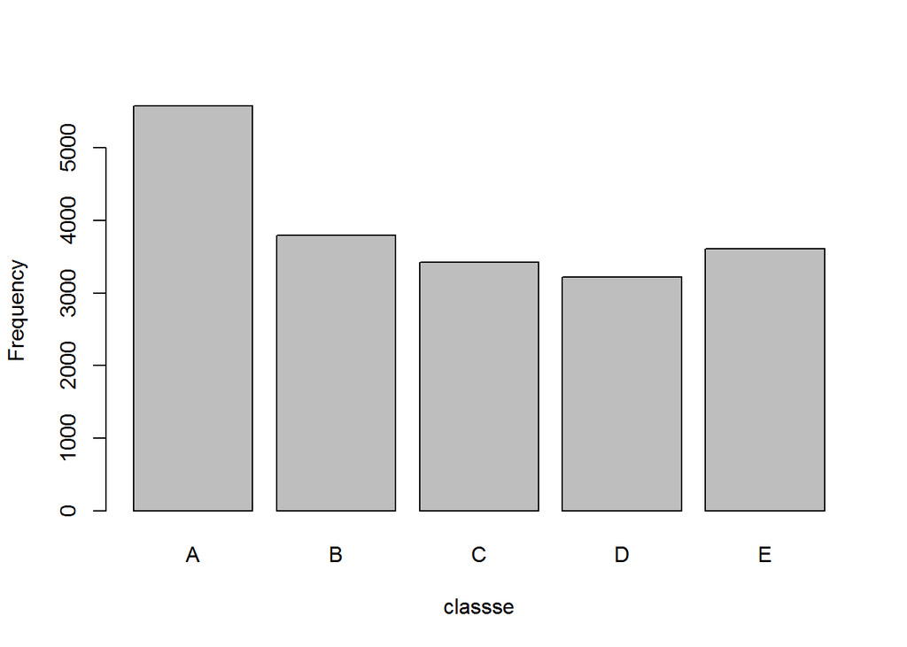

```r
#Plotting classe variable
plot(new_training$classe, xlab="classse", ylab="Frequency")
```

# Cross-validation

## Performed cross-validation by splitting the original training set into a sub training and sub testing test.

```r
# Data splitting
inTrain <- createDataPartition(y=new_training$classe, p=0.75, list=FALSE)
sub_new_training <- new_training[inTrain,]
sub_new_testing <- new_training[-inTrain,]

dim(sub_new_training); dim(sub_new_testing)
```

```
## [1] 14718    53
```

```
## [1] 4904   53
```

# Classification Tress method

## Performed model fit by classificaiton trees method using the train function and invoking Rpart method. Reviewed the Rpart plot. Used the Confusion matrix function and tested the model prediction on the sub testing data set.

```r
#Classification Tress method
Fit1 <- train(classe ~ .,method="rpart",data=sub_new_training)
```

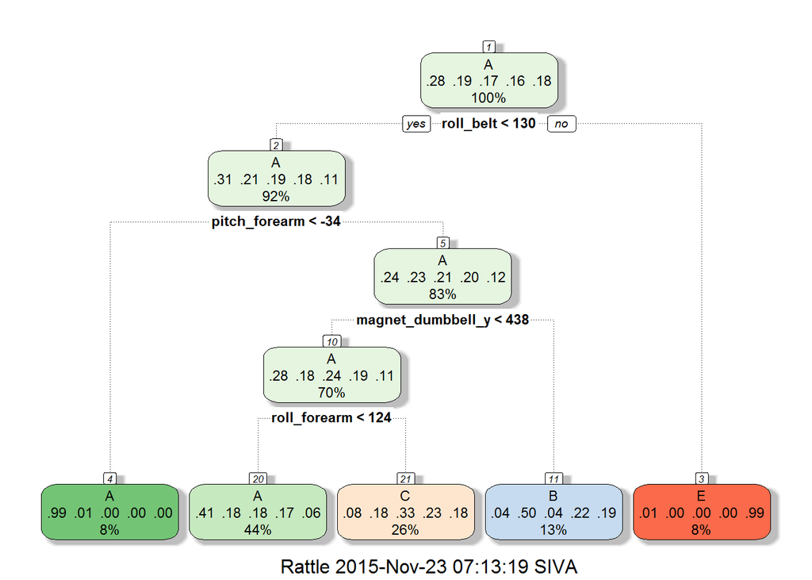

```r
fancyRpartPlot(Fit1$finalModel)
```

```r
confusionMatrix(predict(Fit1,newdata=sub_new_testing),sub_new_testing$classe)
```

```
## Confusion Matrix and Statistics
##
##           Reference
## Prediction    A    B    C    D    E
##          A 1261  385  405  361  140
##          B   22  325   24  145  121
##          C  106  239  426  298  247
##          D    0    0    0    0    0
##          E    6    0    0    0  393
##
## Overall Statistics
##
##                Accuracy : 0.4904
##                  95% CI : (0.4763, 0.5045)
##     No Information Rate : 0.2845
##     P-Value [Acc > NIR] : < 2.2e-16
##
##                   Kappa : 0.334
##  Mcnemar's Test P-Value : NA
##
## Statistics by Class:
##
##                      Class: A Class: B Class: C Class: D Class: E
## Sensitivity            0.9039  0.34247  0.49825   0.0000  0.43618
## Specificity            0.6321  0.92111  0.78019   1.0000  0.99850
## Pos Pred Value         0.4941  0.51020  0.32371      NaN  0.98496
## Neg Pred Value         0.9430  0.85376  0.88043   0.8361  0.88724
## Prevalence             0.2845  0.19352  0.17435   0.1639  0.18373
## Detection Rate         0.2571  0.06627  0.08687   0.0000  0.08014
## Detection Prevalence   0.5204  0.12989  0.26835   0.0000  0.08136
## Balanced Accuracy      0.7680  0.63179  0.63922   0.5000  0.71734
```

### The accuracy is very low.

# Random Forest method

## Since the classification tress didnot yield good result, we performed model fit using Random forest function. Used the Confusion matrix function and tested this model prediction on the sub testing data set.

```r
#Random Forest method
Fit2 <- randomForest(classe ~ ., data=sub_new_training, prox=TRUE)
confusionMatrix(predict(Fit2,newdata=sub_new_testing), sub_new_testing$classe)
```

```
## Confusion Matrix and Statistics
##
##           Reference
## Prediction    A    B    C    D    E
##          A 1394    5    0    0    0
##          B    0  943    4    0    0
##          C    0    1  851    6    0
##          D    0    0    0  796    0
##          E    1    0    0    2  901
##
## Overall Statistics
##
##                Accuracy : 0.9961
##                  95% CI : (0.994, 0.9977)
##     No Information Rate : 0.2845
##     P-Value [Acc > NIR] : < 2.2e-16
##
##                   Kappa : 0.9951
##  Mcnemar's Test P-Value : NA
##
## Statistics by Class:
##
##                      Class: A Class: B Class: C Class: D Class: E
## Sensitivity            0.9993   0.9937   0.9953   0.9900   1.0000
## Specificity            0.9986   0.9990   0.9983   1.0000   0.9993
## Pos Pred Value         0.9964   0.9958   0.9918   1.0000   0.9967
## Neg Pred Value         0.9997   0.9985   0.9990   0.9981   1.0000
## Prevalence             0.2845   0.1935   0.1743   0.1639   0.1837
## Detection Rate         0.2843   0.1923   0.1735   0.1623   0.1837
## Detection Prevalence   0.2853   0.1931   0.1750   0.1623   0.1843
## Balanced Accuracy      0.9989   0.9963   0.9968   0.9950   0.9996
```

### The accuracy is as high as 99%. The sensitivity and the specificity are also high. Hence we will use this model fit to predict on the original testing set.

```r
#Predict the data for test set
pred <- predict(Fit2,newdata=new_testing)
pred
```

```
##  1  2  3  4  5  6  7  8  9 10 11 12 13 14 15 16 17 18 19 20
##  B  A  B  A  A  E  D  B  A  A  B  C  B  A  E  E  A  B  B  B
## Levels: A B C D E
```

# Saving the predicted result for the 20 test data into individual files usin the below function provided by the instructor.

```r
#Saving the predicted data for the 20 test data into individual files for result submission
pml_write_files = function(x){
  n = length(x)
  for(i in 1:n){
    filename = paste0("problem_id_",i,".txt")
    write.table(x[i],file=filename,quote=FALSE,row.names=FALSE,col.names=FALSE)
  }
}

pml_write_files(pred)
```